# index

Title: Project 2: Data Analysis with Pandas

Course: DS 220 – Data Science

Author: Michael Shepherd

Description: This project explores a public dataset using Python and the Pandas library. The goal is to answer data driven questions through exploratory data analysis, visualization, and interpretation, and to present insights in a clear, accessible format.

Problem Space

This project investigates a publicly available dataset to understand patterns, trends, and relationships relevant to the problem domain.

The purpose of this analysis is to:

Understand the structure and content of the dataset

Answer meaningful questions using data analysis

Extract insights that could be useful to stakeholders or decision makers

The analysis focuses on what the data shows, why it matters, and how the results can be interpreted in context.

Dataset Description

The dataset used in this project contains basketball related data from the 2025 season. The data includes team level statistics and performance metrics that can be analyzed to identify trends and relationships.

The dataset was obtained from a publicly available source and stored locally as a CSV file named 2025.csv. It will be loaded into a Pandas DataFrame for cleaning, exploratory analysis, and question driven investigation.

Before analysis, the dataset will be inspected to understand its structure, key variables, and any missing or inconsistent values.

```python
import pandas as pd
import matplotlib.pyplot as plt

df = pd.read_csv("2025.csv")

df.head()
```

|  | Rk | Team | Age | W | L | PW | PL | MOV | SOS | SRS | ... | FT/FGA | Unnamed: 22 | eFG%.1 | TOV%.1 | DRB% | FT/FGA.1 | Unnamed: 27 | Arena | Attend. | Attend./G |
| --- | --- | --- | --- | --- | --- | --- | --- | --- | --- | --- | --- | --- | --- | --- | --- | --- | --- | --- | --- | --- | --- |
| 0 | 1.0 | Oklahoma City Thunder* | 24.8 | 68.0 | 14.0 | 68 | 14 | 12.87 | -0.16 | 12.70 | ... | 0.180 | NaN | 0.513 | 14.9 | 74.6 | 0.211 | NaN | Paycom Center | 754832 | 17973 |
| 1 | 2.0 | Boston Celtics* | 28.9 | 61.0 | 21.0 | 62 | 20 | 9.11 | -0.83 | 8.28 | ... | 0.169 | NaN | 0.522 | 11.6 | 76.0 | 0.154 | NaN | TD Garden | 785396 | 19156 |
| 2 | 3.0 | Cleveland Cavaliers* | 26.6 | 64.0 | 18.0 | 62 | 20 | 9.54 | -0.73 | 8.81 | ... | 0.187 | NaN | 0.528 | 12.6 | 74.8 | 0.181 | NaN | Rocket Arena | 796712 | 19432 |
| 3 | 4.0 | Minnesota Timberwolves* | 27.2 | 49.0 | 33.0 | 53 | 29 | 5.00 | 0.15 | 5.15 | ... | 0.196 | NaN | 0.532 | 13.2 | 75.1 | 0.178 | NaN | Target Center | 772249 | 18835 |
| 4 | 5.0 | Los Angeles Clippers* | 29.7 | 50.0 | 32.0 | 53 | 29 | 4.66 | 0.18 | 4.84 | ... | 0.200 | NaN | 0.536 | 13.7 | 77.5 | 0.189 | NaN | Intuit Dome | 679593 | 16575 |

5 rows × 31 columns

```python
df.info()
```

```
<class 'pandas.core.frame.DataFrame'>
RangeIndex: 31 entries, 0 to 30
Data columns (total 31 columns):
 #   Column       Non-Null Count  Dtype
---  ------       --------------  -----
 0   Rk           30 non-null     float64
 1   Team         31 non-null     object
 2   Age          31 non-null     float64
 3   W            30 non-null     float64
 4   L            30 non-null     float64
 5   PW           31 non-null     int64
 6   PL           31 non-null     int64
 7   MOV          31 non-null     float64
 8   SOS          31 non-null     float64
 9   SRS          31 non-null     float64
```

[output cut: 23 more lines]

Understanding the Dataset

After loading the dataset into a Pandas DataFrame, the structure and contents of the data were examined using basic inspection methods such as head() and info().

The dataset contains multiple columns representing basketball related team statistics from the 2025 season. These columns include both numerical and categorical variables, allowing for quantitative analysis and comparison.

The info() output shows the total number of entries, the data types of each column, and whether any missing values are present. This step is important for determining whether data cleaning or preprocessing is necessary before further analysis.

This understanding provides the foundation for formulating meaningful questions and conducting exploratory data analysis.

Questions to Address

The following questions guide the data analysis performed in this project. nEach question is designed to be answered using the dataset and Python’s Pandas library.

What are the overall distributions of key performance metrics across teams in the 2025 season?

How do teams compare in terms of wins and losses during the 2025 season?

Is there a relationship between team pace and offensive performance metrics?

Which teams rank highest and lowest in selected statistical categories?

How consistent are team performances across different metrics?

Are there noticeable trends or patterns in the data that distinguish higher performing teams from lower performing teams?

```python
df.describe()
```

|  | Rk | Age | W | L | PW | PL | MOV | SOS | SRS | ORtg | ... | ORB% | FT/FGA | Unnamed: 22 | eFG%.1 | TOV%.1 | DRB% | FT/FGA.1 | Unnamed: 27 | Attend. | Attend./G |
| --- | --- | --- | --- | --- | --- | --- | --- | --- | --- | --- | --- | --- | --- | --- | --- | --- | --- | --- | --- | --- | --- |
| count | 30.000000 | 31.000000 | 30.000000 | 30.000000 | 31.000000 | 31.000000 | 3.100000e+01 | 3.100000e+01 | 3.100000e+01 | 31.000000 | ... | 31.000000 | 31.000000 | 0.0 | 31.000000 | 31.000000 | 31.000000 | 31.000000 | 0.0 | 31.000000 | 31.000000 |
| mean | 15.500000 | 26.319355 | 41.000000 | 41.000000 | 40.935484 | 41.064516 | -1.719055e-16 | -1.253478e-17 | -1.146037e-16 | 114.532258 | ... | 25.170968 | 0.189484 | NaN | 0.543000 | 12.664516 | 74.796774 | 0.189613 | NaN | 744036.677419 | 18150.225806 |
| std | 8.803408 | 1.733863 | 13.354581 | 13.354581 | 13.351493 | 13.351493 | 5.893937e+00 | 4.157644e-01 | 5.682646e+00 | 3.796172 | ... | 2.480483 | 0.010788 | NaN | 0.012369 | 1.181397 | 1.475010 | 0.017706 | NaN | 49397.561510 | 1215.839071 |
| min | 1.000000 | 23.500000 | 17.000000 | 14.000000 | 15.000000 | 14.000000 | -1.244000e+01 | -8.300000e-01 | -1.214000e+01 | 106.800000 | ... | 19.300000 | 0.169000 | NaN | 0.513000 | 10.300000 | 71.800000 | 0.154000 | NaN | 657613.000000 | 16084.000000 |
| 25% | 8.250000 | 24.900000 | 34.500000 | 32.000000 | 33.500000 | 31.500000 | -2.990000e+00 | -2.750000e-01 | -2.610000e+00 | 111.800000 | ... | 23.350000 | 0.182000 | NaN | 0.537000 | 11.750000 | 74.100000 | 0.178000 | NaN | 701923.000000 | 17120.000000 |
| 50% | 15.500000 | 26.000000 | 40.500000 | 41.500000 | 42.000000 | 40.000000 | 4.800000e-01 | 1.000000e-02 | 1.100000e-01 | 115.000000 | ... | 25.400000 | 0.189000 | NaN | 0.542000 | 12.600000 | 74.800000 | 0.189000 | NaN | 744037.000000 | 18064.000000 |
| 75% | 22.750000 | 27.500000 | 50.000000 | 47.500000 | 50.500000 | 48.500000 | 3.995000e+00 | 2.750000e-01 | 3.780000e+00 | 116.550000 | ... | 26.400000 | 0.196000 | NaN | 0.550000 | 13.450000 | 76.000000 | 0.202000 | NaN | 783662.500000 | 19113.500000 |
| max | 30.000000 | 29.700000 | 68.000000 | 65.000000 | 68.000000 | 67.000000 | 1.287000e+01 | 8.400000e-01 | 1.270000e+01 | 121.700000 | ... | 31.700000 | 0.213000 | NaN | 0.570000 | 15.000000 | 77.500000 | 0.222000 | NaN | 825659.000000 | 20138.000000 |

8 rows × 29 columns

```python
df.columns
```

```
Index(['Rk', 'Team', 'Age', 'W', 'L', 'PW', 'PL', 'MOV', 'SOS', 'SRS', 'ORtg',
       'DRtg', 'NRtg', 'Pace', 'FTr', '3PAr', 'TS%', 'Unnamed: 17', 'eFG%',
       'TOV%', 'ORB%', 'FT/FGA', 'Unnamed: 22', 'eFG%.1', 'TOV%.1', 'DRB%',
       'FT/FGA.1', 'Unnamed: 27', 'Arena', 'Attend.', 'Attend./G'],
      dtype='object')
```

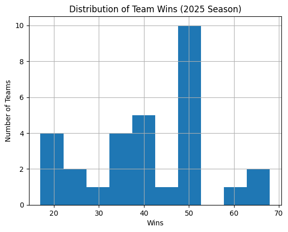

```python
plt.figure()
df["W"].hist()
plt.title("Distribution of Team Wins (2025 Season)")
plt.xlabel("Wins")
plt.ylabel("Number of Teams")
plt.show()
```

Exploratory Data Analysis

Initial exploratory analysis was conducted to better understand the overall distribution and range of values within the dataset. Summary statistics were used to observe central tendencies and variability across numerical columns.

A histogram of team wins provides an overview of how performance is distributed across the league during the 2025 season. This visualization helps identify whether wins are evenly distributed or clustered around certain values.

These exploratory steps help guide deeper analysis and support the questions outlined earlier.

Question 1: Distribution of Key Performance Metrics

This question examines the overall distributions of selected performance metrics across teams during the 2025 season. Understanding these distributions helps identify typical values, variability, and potential outliers in team performance.

```python
key_metrics = ["W", "L", "Pace", "3PAr"]
df[key_metrics].describe()
```

|  | W | L | Pace | 3PAr |
| --- | --- | --- | --- | --- |
| count | 30.000000 | 30.000000 | 31.000000 | 31.000000 |
| mean | 41.000000 | 41.000000 | 98.845161 | 0.421194 |
| std | 13.354581 | 13.354581 | 1.911341 | 0.035593 |
| min | 17.000000 | 14.000000 | 95.700000 | 0.356000 |
| 25% | 34.500000 | 32.000000 | 97.450000 | 0.392500 |
| 50% | 40.500000 | 41.500000 | 98.800000 | 0.421000 |
| 75% | 50.000000 | 47.500000 | 99.800000 | 0.440500 |
| max | 68.000000 | 65.000000 | 103.300000 | 0.536000 |

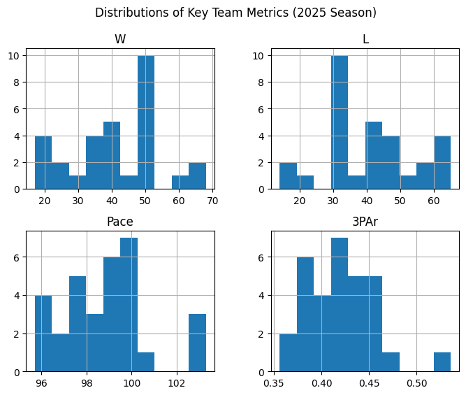

```python
df[key_metrics].hist(figsize=(8, 6))
plt.suptitle("Distributions of Key Team Metrics (2025 Season)")
plt.show()
```

Answer to Question 1

The summary statistics and histograms show how key team performance metrics are distributed across the league. Wins and losses appear centered around mid range values, reflecting competitive balance among teams.

Metrics such as pace and three point attempt rate display noticeable variation, suggesting differences in team play styles and offensive strategies. These distributions provide important context for comparing teams and interpreting performance in later analyses.

Question 2: Comparison of Wins and Losses

This question compares team performance in terms of wins and losses during the 2025 season. Examining this relationship helps identify overall standings and performance differences across teams.

```python
df[["Team", "W", "L"]].sort_values(by="W", ascending=False).head(10)
```

|  | Team | W | L |
| --- | --- | --- | --- |
| 0 | Oklahoma City Thunder* | 68.0 | 14.0 |
| 2 | Cleveland Cavaliers* | 64.0 | 18.0 |
| 1 | Boston Celtics* | 61.0 | 21.0 |
| 6 | Houston Rockets* | 52.0 | 30.0 |
| 7 | New York Knicks* | 51.0 | 31.0 |
| 4 | Los Angeles Clippers* | 50.0 | 32.0 |
| 13 | Los Angeles Lakers* | 50.0 | 32.0 |
| 11 | Indiana Pacers* | 50.0 | 32.0 |
| 8 | Denver Nuggets* | 50.0 | 32.0 |
| 3 | Minnesota Timberwolves* | 49.0 | 33.0 |

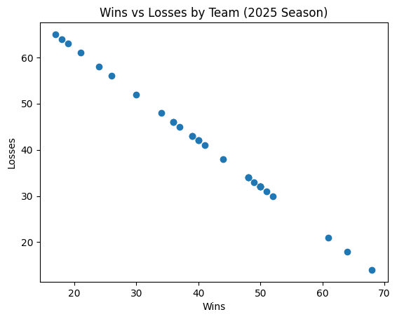

```python
plt.figure()
plt.scatter(df["W"], df["L"])
plt.xlabel("Wins")
plt.ylabel("Losses")
plt.title("Wins vs Losses by Team (2025 Season)")
plt.show()
```

Answer to Question 2

The comparison of wins and losses highlights clear differences in team performance across the league. Teams with higher win totals generally have lower loss totals, reflecting expected competitive outcomes.

The scatter plot illustrates an inverse relationship between wins and losses, showing how team success is distributed along a performance spectrum. This visual comparison helps distinguish top performing teams from those with struggles during the season.

Question 3: Relationship Between Pace and Offensive Performance

This question explores whether a relationship exists between team pace and offensive performance during the 2025 season. Pace reflects the speed at which a team plays, while offensive metrics indicate scoring tendencies.

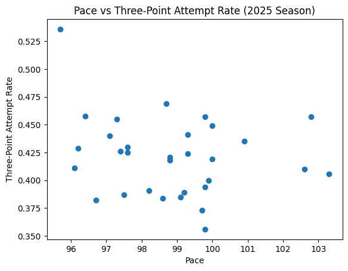

```python
plt.figure()
plt.scatter(df["Pace"], df["3PAr"])
plt.xlabel("Pace")
plt.ylabel("Three-Point Attempt Rate")
plt.title("Pace vs Three-Point Attempt Rate (2025 Season)")
plt.show()
```

```python
df[["Pace", "3PAr"]].corr()
```

|  | Pace | 3PAr |
| --- | --- | --- |
| Pace | 1.000000 | -0.214452 |
| 3PAr | -0.214452 | 1.000000 |

Answer to Question 3

The scatter plot and correlation analysis suggest how pace relates to offensive style across teams. The relationship between pace and three point attempt rate indicates whether faster paced teams tend to rely more heavily on perimeter shooting.

Question 4: Teams Ranking Highest and Lowest in Key Metrics

This question identifies teams that rank at the top and bottom of selected performance metrics during the 2025 season. Ranking teams helps highlight extreme performers and contrasts different levels of success.

```python
top_teams = df[["Team", "W"]].sort_values(by="W", ascending=False).head(5)
bottom_teams = df[["Team", "W"]].sort_values(by="W").head(5)

top_teams, bottom_teams
```

```
(                     Team     W
 0  Oklahoma City Thunder*  68.0
 2    Cleveland Cavaliers*  64.0
 1         Boston Celtics*  61.0
 6        Houston Rockets*  52.0
 7        New York Knicks*  51.0,
                     Team     W
 26             Utah Jazz  17.0
 29    Washington Wizards  18.0
 27     Charlotte Hornets  19.0
 28  New Orleans Pelicans  21.0
 24    Philadelphia 76ers  24.0)
```

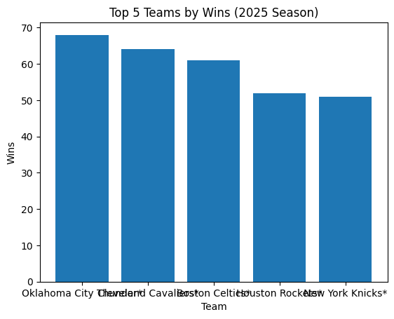

```python
plt.figure()
plt.bar(top_teams["Team"], top_teams["W"])
plt.title("Top 5 Teams by Wins (2025 Season)")
plt.xlabel("Team")
plt.ylabel("Wins")
plt.show()
```

Answer to Question 4

Ranking teams by wins highlights the strongest and weakest performers in the league during the 2025 season. The top teams demonstrate consistently high performance, while teams at the bottom reflect challenges in competitiveness.

Visualizing the top teams by wins provides a clear comparison of success levels and helps contextualize how performance differs across the league.

Question 5: Consistency of Team Performance Across Metrics

This question examines how consistent teams are across multiple performance metrics. Consistency can indicate overall balance, while large variation may suggest reliance on specific strengths or weaknesses.

```python
metrics = ["W", "L", "Pace", "3PAr"]
df["Metric_Std"] = df[metrics].std(axis=1)

df[["Team", "Metric_Std"]].sort_values(by="Metric_Std").head(10)
```

|  | Team | Metric_Std |
| --- | --- | --- |
| 16 | Orlando Magic* | 39.288822 |
| 14 | Miami Heat* | 39.461138 |
| 22 | Phoenix Suns | 39.924724 |
| 15 | Sacramento Kings | 40.224850 |
| 3 | Minnesota Timberwolves* | 40.330022 |
| 7 | New York Knicks* | 40.395731 |
| 4 | Los Angeles Clippers* | 40.581468 |
| 13 | Los Angeles Lakers* | 40.610715 |
| 21 | Portland Trail Blazers | 40.676053 |
| 18 | Dallas Mavericks | 40.690499 |

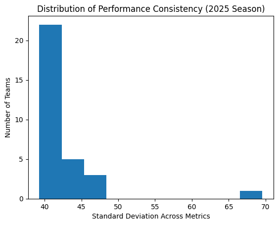

```python
plt.figure()
plt.hist(df["Metric_Std"])
plt.title("Distribution of Performance Consistency (2025 Season)")
plt.xlabel("Standard Deviation Across Metrics")
plt.ylabel("Number of Teams")
plt.show()
```

Answer to Question 5

Analyzing the standard deviation across multiple metrics provides insight into team consistency. Teams with lower standard deviation values tend to perform more evenly across different aspects of the game.

The distribution shows that while some teams maintain balanced performance, others display greater variability, indicating dependence on certain strengths or exposure to specific weaknesses.

Question 6: Patterns Distinguishing High and Low Performing Teams

This question examines whether there are noticeable patterns in performance metrics that distinguish higher performing teams from lower performing teams during the 2025 season.

```python
median_wins = df["W"].median()

high_performers = df[df["W"] >= median_wins]
low_performers = df[df["W"] < median_wins]

high_performers[["W", "Pace", "3PAr"]].mean(), low_performers[["W", "Pace", "3PAr"]].mean()
```

```
(W       51.600000
 Pace    98.673333
 3PAr     0.420333
 dtype: float64,
 W       30.400000
 Pace    99.020000
 3PAr     0.422067
 dtype: float64)
```

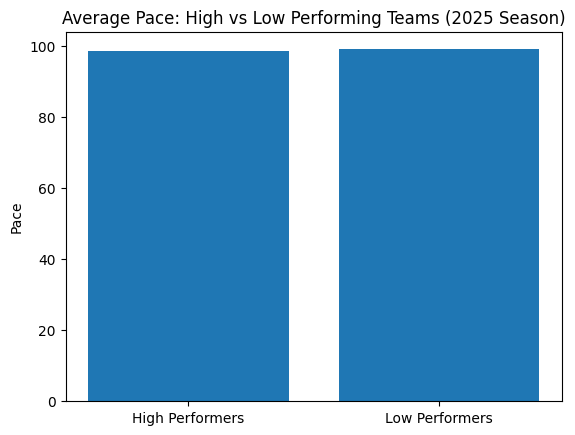

```python
labels = ["High Performers", "Low Performers"]
pace_means = [high_performers["Pace"].mean(), low_performers["Pace"].mean()]

plt.figure()
plt.bar(labels, pace_means)
plt.title("Average Pace: High vs Low Performing Teams (2025 Season)")
plt.ylabel("Pace")
plt.show()
```

Insights and Conclusion

This analysis of 2025 basketball team data demonstrates how Pandas can be used to explore, summarize, and interpret performance metrics. Through exploratory analysis and targeted questions, patterns in team success and playing style were identified.

Overall, this project shows the value of using Python and Pandas for structured data analysis and emphasizes the importance of clear questions, visualizations, and interpretation when communicating results.